# Credit Risk project - binary classification models comparison

Mateusz Majak, Huseyin Can Minareci, Damian Żamojda

11 06 2021

# 1 Introduction

As a final project, using the knowledge gained from the classes, we will compare several binary classification models using dataset consisting binary target variable.

Purpose of the models will be to predict next-day rain by training classification models on the target variable RainTomorrow.

# 2 About the dataset

The dataset used in this project contains about 10 years of daily weather observations from many locations across Australia. It was shared by Joe Young on the Kaggle platform and is available here.

# 3 Preparations

## 3.1 Load libraries

We load multiple libraries for data manipulation and visualisation together with tools for data modelling.

```r
# data manipulation
library(tidyverse)
library(tidyr)
library(mice)
```

```r
#visualizations
library(ggplot2)
library(ggthemes)
library(scales)
library(extrafont)
library(viridis)
loadfonts()
library(gridExtra)
library(grid)
#modeling
library(caret)
library(corrplot)
library(gbm)
library(xgboost)
library(here)
```

## 3.2 Load Data

We load the whole data from csv files.

```r
rain_data <- read.csv("weatherAUS.csv")
```

## 3.3 Data manipulation

We change column data types and deal with NAs when needed.

```r
#Data types convertion
rain_data$Date <- as.Date(rain_data$Date)
rain_data$Location <- as.factor(rain_data$Location)
rain_data$RainToday <- as.factor(rain_data$RainToday)
rain_data$RainTomorrow <- as.factor(rain_data$RainTomorrow)
rain_data$WindGustDir <- as.factor(rain_data$WindGustDir)
rain_data$WindDir9am <- as.factor(rain_data$WindDir9am)
rain_data$WindDir3pm <- as.factor(rain_data$WindDir3pm)
#NA values
colSums(is.na(rain_data)) %>%
  sort()
```

```
##          Date      Location       MaxTemp       MinTemp  WindSpeed9am
##             0             0          1261          1485          1767
##       Temp9am   Humidity9am  WindSpeed3pm      Rainfall     RainToday
##          1767          2654          3062          3261          3261
##  RainTomorrow       Temp3pm    WindDir3pm   Humidity3pm WindGustSpeed
##          3267          3609          4228          4507         10263
##   WindGustDir    WindDir9am   Pressure3pm   Pressure9am      Cloud9am
##         10326         10566         15028         15065         55888
##      Cloud3pm   Evaporation      Sunshine
##         59358         62790         69835
```

```r
table(rain_data$RainToday, useNA = "ifany")
```

```
##
##     No    Yes   <NA>
## 110319  31880   3261
```

```r
table(rain_data$RainTomorrow, useNA = "ifany")
```

```
##
##     No    Yes   <NA>
## 110316  31877   3267
```

```r
#There are many NA values, thus we deal with it in the next steps
```

# 4 Data preview

The dataset contains **145 460** rows and **23** columns.

This is how it looks like:

```r
glimpse(rain_data)
```

```
## Rows: 145,460
## Columns: 23
## $ Date          <date> 2008-12-01, 2008-12-02, 2008-12-03, 2008-12-04, 2008...
## $ Location      <fct> Albury, Albury, Albury, Albury, Albury, Albury, Albur...
## $ MinTemp       <dbl> 13.4, 7.4, 12.9, 9.2, 17.5, 14.6, 14.3, 7.7, 9.7, 13....
## $ MaxTemp       <dbl> 22.9, 25.1, 25.7, 28.0, 32.3, 29.7, 25.0, 26.7, 31.9,...
## $ Rainfall      <dbl> 0.6, 0.0, 0.0, 0.0, 1.0, 0.2, 0.0, 0.0, 0.0, 1.4, 0.0...
## $ Evaporation   <dbl> NA, NA, NA, NA, NA, NA, NA, NA, NA, NA, NA, NA, NA, N...
## $ Sunshine      <dbl> NA, NA, NA, NA, NA, NA, NA, NA, NA, NA, NA, NA, NA, N...
## $ WindGustDir   <fct> W, WNW, WSW, NE, W, WNW, W, W, NNW, W, N, NNE, W, SW,...
## $ WindGustSpeed <int> 44, 44, 46, 24, 41, 56, 50, 35, 80, 28, 30, 31, 61, 4...
## $ WindDir9am    <fct> W, NNW, W, SE, ENE, W, SW, SSE, SE, S, SSE, NE, NNW, ...
## $ WindDir3pm    <fct> WNW, WSW, WSW, E, NW, W, W, W, NW, SSE, ESE, ENE, NNW...
## $ WindSpeed9am  <int> 20, 4, 19, 11, 7, 19, 20, 6, 7, 15, 17, 15, 28, 24, 4...
## $ WindSpeed3pm  <int> 24, 22, 26, 9, 20, 24, 24, 17, 28, 11, 6, 13, 28, 20,...
## $ Humidity9am   <int> 71, 44, 38, 45, 82, 55, 49, 48, 42, 58, 48, 89, 76, 6...
## $ Humidity3pm   <int> 22, 25, 30, 16, 33, 23, 19, 19, 9, 27, 22, 91, 93, 43...
## $ Pressure9am   <dbl> 1007.7, 1010.6, 1007.6, 1017.6, 1010.8, 1009.2, 1009....
## $ Pressure3pm   <dbl> 1007.1, 1007.8, 1008.7, 1012.8, 1006.0, 1005.4, 1008....
## $ Cloud9am      <int> 8, NA, NA, NA, 7, NA, 1, NA, NA, NA, NA, 8, 8, NA, NA...
## $ Cloud3pm      <int> NA, NA, 2, NA, 8, NA, NA, NA, NA, NA, NA, 8, 8, 7, NA...
## $ Temp9am       <dbl> 16.9, 17.2, 21.0, 18.1, 17.8, 20.6, 18.1, 16.3, 18.3,...
## $ Temp3pm       <dbl> 21.8, 24.3, 23.2, 26.5, 29.7, 28.9, 24.6, 25.5, 30.2,...
## $ RainToday     <fct> No, No, No, No, No, No, No, No, No, Yes, No, Yes, Yes...
## $ RainTomorrow  <fct> No, No, No, No, No, No, No, No, Yes, No, Yes, Yes, Ye...
```

```r
head(rain_data)
```

```
##         Date Location MinTemp MaxTemp Rainfall Evaporation Sunshine WindGustDir
## 1 2008-12-01   Albury    13.4    22.9      0.6          NA       NA           W
## 2 2008-12-02   Albury     7.4    25.1      0.0          NA       NA         WNW
## 3 2008-12-03   Albury    12.9    25.7      0.0          NA       NA         WSW
## 4 2008-12-04   Albury     9.2    28.0      0.0          NA       NA          NE
## 5 2008-12-05   Albury    17.5    32.3      1.0          NA       NA           W
## 6 2008-12-06   Albury    14.6    29.7      0.2          NA       NA         WNW
##   WindGustSpeed WindDir9am WindDir3pm WindSpeed9am WindSpeed3pm Humidity9am
## 1            44          W        WNW           20           24          71
## 2            44        NNW        WSW            4           22          44
## 3            46          W        WSW           19           26          38
## 4            24         SE          E           11            9          45
## 5            41        ENE         NW            7           20          82
## 6            56          W          W           19           24          55
##   Humidity3pm Pressure9am Pressure3pm Cloud9am Cloud3pm Temp9am Temp3pm
## 1          22      1007.7      1007.1        8       NA    16.9    21.8
## 2          25      1010.6      1007.8       NA       NA    17.2    24.3
## 3          30      1007.6      1008.7       NA        2    21.0    23.2
## 4          16      1017.6      1012.8       NA       NA    18.1    26.5
## 5          33      1010.8      1006.0        7        8    17.8    29.7
## 6          23      1009.2      1005.4       NA       NA    20.6    28.9
##   RainToday RainTomorrow
## 1        No           No
## 2        No           No
## 3        No           No
## 4        No           No
## 5        No           No
## 6        No           No
```

# 5 Missing values

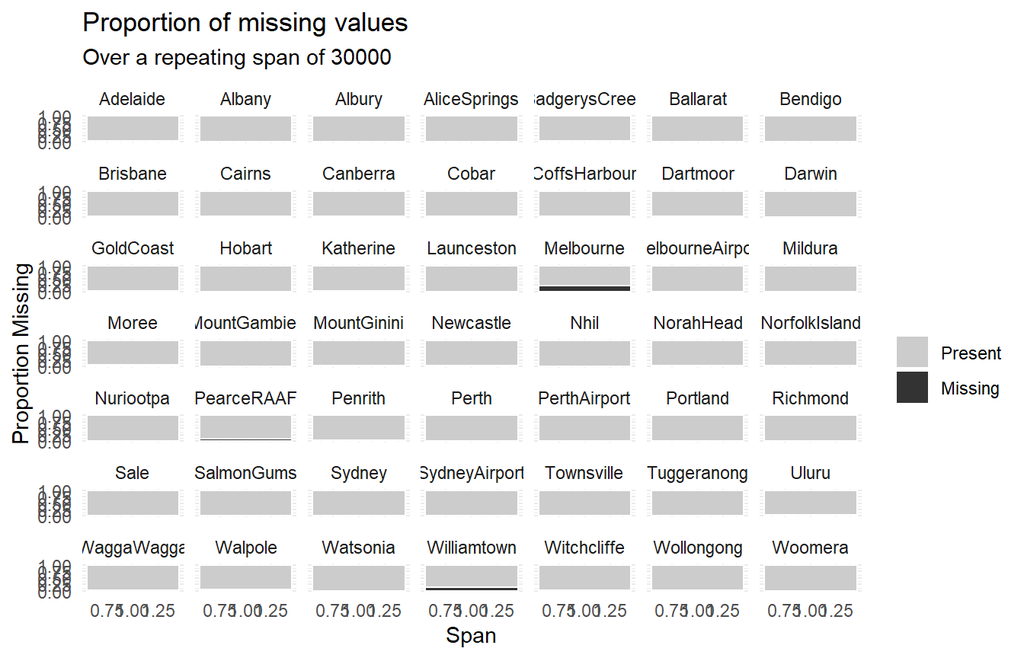

```r
library(naniar)
rain_data %>%
gg_miss_span(RainTomorrow,
             span_every = 30000,
             facet = Location)
```

There are 2 cities containing significant number of missing values in dependent variable: Melbourne and Williamtown. We consider removing all rows with the data from these cities or just rows with NA values. For now we will keep all the data, but we save information about rows with the null dependent variable.

```r
NA_cities <- which(is.na(rain_data$RainTomorrow))
rain_data[NA_cities[1:10],]
```

```
##           Date Location MinTemp MaxTemp Rainfall Evaporation Sunshine
## 15  2008-12-15   Albury     8.4    24.6      0.0          NA       NA
## 284 2009-09-10   Albury     2.6      NA      0.0          NA       NA
## 436 2010-02-09   Albury    22.1    35.1      0.0          NA       NA
## 438 2010-02-11   Albury    21.5    35.0      0.0          NA       NA
## 444 2010-02-17   Albury    15.5    30.6      0.0          NA       NA
## 453 2010-02-26   Albury    17.2      NA      0.0          NA       NA
## 456 2010-03-01   Albury    14.4      NA      0.0          NA       NA
## 465 2010-03-10   Albury     8.8      NA      0.0          NA       NA
## 612 2010-08-04   Albury     1.2     9.6      0.0          NA       NA
## 984 2011-09-10   Albury     4.0      NA      0.2          NA       NA
##     WindGustDir WindGustSpeed WindDir9am WindDir3pm WindSpeed9am WindSpeed3pm
## 15         <NA>            NA          S        WNW            4           30
## 284        <NA>            NA          E        WNW            6           13
## 436        <NA>            NA        ENE         SW            6           11
```

[output cut: 29 more lines]

Additionally, we check other variables for missing values.

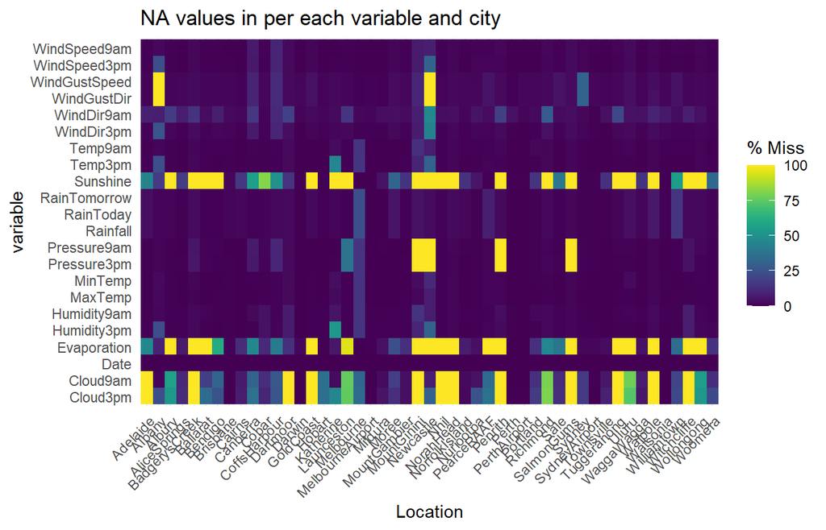

```r
gg_miss_fct(x = rain_data, fct = Location) + labs(title = "NA values in per each variable and city")
```

It seems there are a lot of NA values in Sunshine, Evaporation, Cloud9am and Cloud3pm columns.

# 6 Data division

```r
set.seed(987654321)

rain_which_train <- createDataPartition(rain_data$RainTomorrow,
                                          p = 0.7,
                                          list = FALSE)

rain_train <- rain_data[rain_which_train,]
rain_test <- rain_data[-rain_which_train,]

prop.table(table(rain_data$RainTomorrow))
```

```
##
##        No       Yes
## 0.7758188 0.2241812
```

```r
prop.table(table(rain_train$RainTomorrow))
```

```
##
##        No       Yes
## 0.7758198 0.2241802
```

```r
prop.table(table(rain_test$RainTomorrow))
```

```
##
##        No       Yes
## 0.7758164 0.2241836
```

Proportion of target variable didn’t significantly change after splitting the dataset.

# 7 EDA

## 7.1 Variables division by type

We group variables by type and save them into list to analyze them later.

```r
# some plots here (histogram, relationships with the independent variables?)
rain_numeric_vars <-
  sapply(rain_train, is.numeric) %>%
  which() %>%
  names()

rain_factor_vars <-
  sapply(rain_train, is.factor) %>%
  which() %>%
  names()

rain_factor_vars <- rain_factor_vars[1:5]

rain_numeric_vars
```

```
##  [1] "MinTemp"       "MaxTemp"       "Rainfall"      "Evaporation"
##  [5] "Sunshine"      "WindGustSpeed" "WindSpeed9am"  "WindSpeed3pm"
##  [9] "Humidity9am"   "Humidity3pm"   "Pressure9am"   "Pressure3pm"
## [13] "Cloud9am"      "Cloud3pm"      "Temp9am"       "Temp3pm"
```

```r
rain_factor_vars
```

```
## [1] "Location"    "WindGustDir" "WindDir9am"  "WindDir3pm"  "RainToday"
```

## 7.2 Correlation

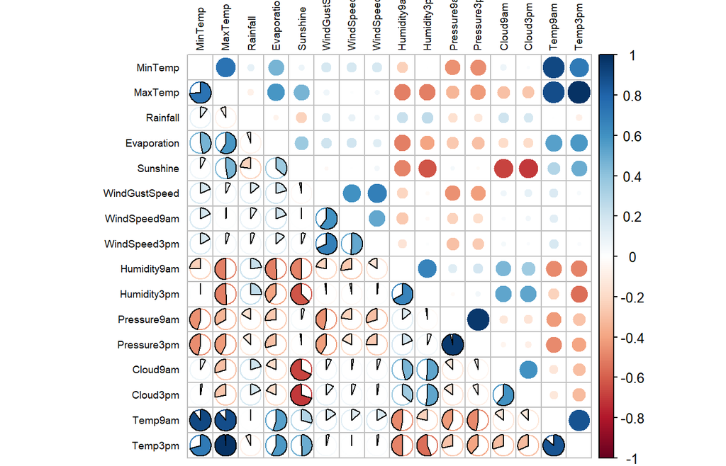

```r
rain_correlations <-
  cor(rain_train[,rain_numeric_vars],
      use = "pairwise.complete.obs")

rain_numeric_vars_order <-
  rain_train[,"RainTomorrow"] %>%
  sort(decreasing = TRUE) %>%
  names()

corrplot.mixed(rain_correlations,
               upper = "circle",
               lower = "pie",
               tl.col="black",
               tl.pos = "lt",
               tl.cex = 0.6)
```

We can see that there are a few groups of variables highly correlated with each other. Temp3am, Temp9am, MinTemp and MaxTemp are positively correlated which is quite intuitive. Pressure3pm is positively correlated with Pressure9am which is also intuitive. Finally, Cloud9am and Cloud3pm are negatively correlated with Sunshine, which is intuitive as well.

## 7.3 Dependent variable

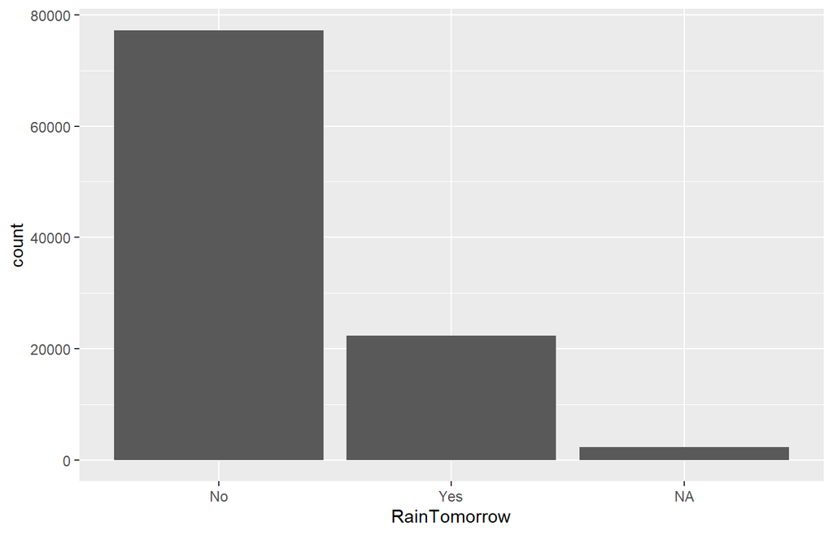

```r
ggplot(rain_train) + geom_bar(aes(x = RainTomorrow))
```

Variable is unbalanced, we will consider dealing with it later.

## 7.4 Independent Variables

### 7.4.1 Numeric variables

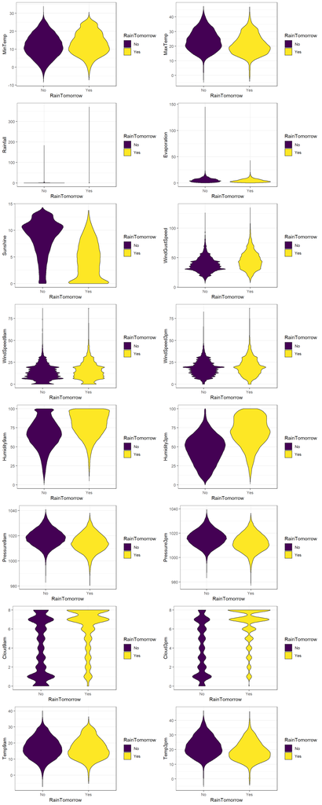

```r
p1 <-
  rain_train %>%
  dplyr::filter(!is.na(RainTomorrow)) %>%
  ggplot(aes(x=RainTomorrow, y=MinTemp, fill= RainTomorrow)) + geom_violin() + scale_fill_viridis(discrete=TRUE, option="viridis") + scale_color_viridis(option="viridis") +  theme_bw()

p2 <-
  rain_train %>%
  dplyr::filter(!is.na(RainTomorrow)) %>%
  ggplot(aes(x=RainTomorrow, y=MaxTemp, fill= RainTomorrow)) + geom_violin() + scale_fill_viridis(discrete=TRUE, option="viridis") + scale_color_viridis(option="viridis") +  theme_bw()

p3 <-
  rain_train %>%
  dplyr::filter(!is.na(RainTomorrow)) %>%
  ggplot(aes(x=RainTomorrow, y=Rainfall, fill= RainTomorrow)) + geom_violin() + scale_fill_viridis(discrete=TRUE, option="viridis") + scale_color_viridis(option="viridis") +  theme_bw()

p4 <-
  rain_train %>%
  dplyr::filter(!is.na(RainTomorrow)) %>%
  ggplot(aes(x=RainTomorrow, y=Evaporation, fill= RainTomorrow)) + geom_violin() + scale_fill_viridis(discrete=TRUE, option="viridis") + scale_color_viridis(option="viridis") +  theme_bw()

p5 <-
  rain_train %>%
  dplyr::filter(!is.na(RainTomorrow)) %>%
  ggplot(aes(x=RainTomorrow, y=Sunshine, fill= RainTomorrow)) + geom_violin() + scale_fill_viridis(discrete=TRUE, option="viridis") + scale_color_viridis(option="viridis") +  theme_bw()

p6 <-
  rain_train %>%
  dplyr::filter(!is.na(RainTomorrow)) %>%
  ggplot(aes(x=RainTomorrow, y=WindGustSpeed, fill= RainTomorrow)) + geom_violin() + scale_fill_viridis(discrete=TRUE, option="viridis") + scale_color_viridis(option="viridis") +  theme_bw()

p7 <-
  rain_train %>%
  dplyr::filter(!is.na(RainTomorrow)) %>%
  ggplot(aes(x=RainTomorrow, y=WindSpeed9am, fill= RainTomorrow)) + geom_violin() + scale_fill_viridis(discrete=TRUE, option="viridis") + scale_color_viridis(option="viridis") +  theme_bw()

p8 <-
  rain_train %>%
  dplyr::filter(!is.na(RainTomorrow)) %>%
  ggplot(aes(x=RainTomorrow, y=WindSpeed3pm, fill= RainTomorrow)) + geom_violin() + scale_fill_viridis(discrete=TRUE, option="viridis") + scale_color_viridis(option="viridis") +  theme_bw()

p9 <-
  rain_train %>%
  dplyr::filter(!is.na(RainTomorrow)) %>%
  ggplot(aes(x=RainTomorrow, y=Humidity9am, fill= RainTomorrow)) + geom_violin() + scale_fill_viridis(discrete=TRUE, option="viridis") + scale_color_viridis(option="viridis") +  theme_bw()

p10 <-
  rain_train %>%
  dplyr::filter(!is.na(RainTomorrow)) %>%
  ggplot(aes(x=RainTomorrow, y=Humidity3pm, fill= RainTomorrow)) + geom_violin() + scale_fill_viridis(discrete=TRUE, option="viridis") + scale_color_viridis(option="viridis") +  theme_bw()

p11 <-
  rain_train %>%
  dplyr::filter(!is.na(RainTomorrow)) %>%
  ggplot(aes(x=RainTomorrow, y=Pressure9am, fill= RainTomorrow)) + geom_violin() + scale_fill_viridis(discrete=TRUE, option="viridis") + scale_color_viridis(option="viridis") +  theme_bw()

p12 <-
  rain_train %>%
  dplyr::filter(!is.na(RainTomorrow)) %>%
  ggplot(aes(x=RainTomorrow, y=Pressure3pm, fill= RainTomorrow)) + geom_violin() + scale_fill_viridis(discrete=TRUE, option="viridis") + scale_color_viridis(option="viridis") +  theme_bw()

p13 <-
  rain_train %>%
  dplyr::filter(!is.na(RainTomorrow)) %>%
  ggplot(aes(x=RainTomorrow, y=Cloud9am, fill= RainTomorrow)) + geom_violin() + scale_fill_viridis(discrete=TRUE, option="viridis") + scale_color_viridis(option="viridis") +  theme_bw()

p14 <-
  rain_train %>%
  dplyr::filter(!is.na(RainTomorrow)) %>%
  ggplot(aes(x=RainTomorrow, y=Cloud3pm, fill= RainTomorrow)) + geom_violin() + scale_fill_viridis(discrete=TRUE, option="viridis") + scale_color_viridis(option="viridis") +  theme_bw()

p15 <-
  rain_train %>%
  dplyr::filter(!is.na(RainTomorrow)) %>%
  ggplot(aes(x=RainTomorrow, y=Temp9am, fill= RainTomorrow)) + geom_violin() + scale_fill_viridis(discrete=TRUE, option="viridis") + scale_color_viridis(option="viridis") +  theme_bw()

p16 <-
  rain_train %>%
  dplyr::filter(!is.na(RainTomorrow)) %>%
  ggplot(aes(x=RainTomorrow, y=Temp3pm, fill= RainTomorrow)) + geom_violin() + scale_fill_viridis(discrete=TRUE, option="viridis") + scale_color_viridis(option="viridis") +  theme_bw()



grid.arrange(p1, p2, p3, p4, p5, p6, p7, p8,
             p9, p10, p11, p12, p13, p14, p15, p16,
             nrow = 8, ncol = 2)
```

We can visually recognize differences between distributions of Sunshine, Cloud9am, Cloud3pm and humidity variables with the target variable on the x axis.

### 7.4.2 Factor variables

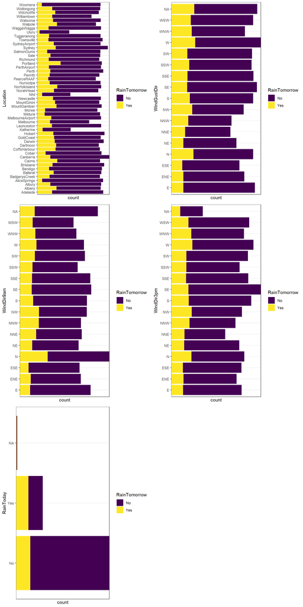

```r
fp1 <- rain_train %>%
  dplyr::filter(!is.na(RainTomorrow)) %>%
  ggplot(aes(fill = RainTomorrow)) +
  geom_bar(aes(y = Location)) +
  scale_x_discrete(expand = c(0, 0)) + scale_fill_viridis(discrete=TRUE, option="viridis") + scale_color_viridis(option="viridis") +  theme_bw()

fp2 <- rain_train %>%
  dplyr::filter(!is.na(RainTomorrow)) %>%
  ggplot(aes(fill = RainTomorrow)) +
  geom_bar(aes(y = WindGustDir)) +
  scale_x_discrete(expand = c(0, 0)) + scale_fill_viridis(discrete=TRUE, option="viridis") + scale_color_viridis(option="viridis") +  theme_bw()

fp3 <- rain_train %>%
  dplyr::filter(!is.na(RainTomorrow)) %>%
  ggplot(aes(fill = RainTomorrow)) +
  geom_bar(aes(y = WindDir9am)) +
  scale_x_discrete(expand = c(0, 0)) + scale_fill_viridis(discrete=TRUE, option="viridis") + scale_color_viridis(option="viridis") +  theme_bw()

fp4 <- rain_train %>%
  dplyr::filter(!is.na(RainTomorrow)) %>%
  ggplot(aes(fill = RainTomorrow)) +
  geom_bar(aes(y = WindDir3pm)) +
  scale_x_discrete(expand = c(0, 0)) + scale_fill_viridis(discrete=TRUE, option="viridis") + scale_color_viridis(option="viridis") +  theme_bw()

fp5 <- rain_train %>%
  dplyr::filter(!is.na(RainTomorrow)) %>%
  ggplot(aes(fill = RainTomorrow)) +
  geom_bar(aes(y = RainToday)) +
  scale_x_discrete(expand = c(0, 0)) + scale_fill_viridis(discrete=TRUE, option="viridis") + scale_color_viridis(option="viridis") +  theme_bw()

grid.arrange(fp1, fp2, fp3, fp4, fp5,
             nrow = 3, ncol = 2)
```

# 8 Modeling

## 8.1 Data Preparation

```r
getmode <- function(v) {
   uniqv <- unique(v)
   uniqv[which.max(tabulate(match(v, uniqv)))]
}

rain_train$MinTemp <- replace_na(rain_train$MinTemp, mean(rain_train$MinTemp, na.rm=TRUE))
rain_train$MaxTemp <- replace_na(rain_train$MaxTemp, mean(rain_train$MaxTemp, na.rm=TRUE))
rain_train$Rainfall <- replace_na(rain_train$Rainfall, mean(rain_train$Rainfall, na.rm=TRUE))
rain_train$Evaporation <- replace_na(rain_train$Evaporation, mean(rain_train$Evaporation, na.rm=TRUE))
rain_train$Sunshine <- replace_na(rain_train$Sunshine, mean(rain_train$Sunshine, na.rm=TRUE))
rain_train$WindGustDir <- replace_na(rain_train$WindGustDir, getmode(rain_train$WindGustDir))
rain_train$WindGustSpeed <- replace_na(rain_train$WindGustSpeed, mean(rain_train$WindGustSpeed, na.rm=TRUE))
rain_train$WindDir9am <- replace_na(rain_train$WindDir9am, getmode(rain_train$WindDir9am))
rain_train$WindDir3pm <- replace_na(rain_train$WindDir3pm, getmode(rain_train$WindDir3pm))
rain_train$WindSpeed9am <- replace_na(rain_train$WindSpeed9am, mean(rain_train$WindSpeed9am, na.rm=TRUE))
rain_train$WindSpeed3pm <- replace_na(rain_train$WindSpeed3pm, mean(rain_train$WindSpeed3pm, na.rm=TRUE))
rain_train$Humidity9am <- replace_na(rain_train$Humidity9am, mean(rain_train$Humidity9am, na.rm=TRUE))
rain_train$Pressure9am <- replace_na(rain_train$Pressure9am, mean(rain_train$Pressure9am, na.rm=TRUE))
rain_train$Cloud9am <- replace_na(rain_train$Cloud9am, mean(rain_train$Cloud9am, na.rm=TRUE))
rain_train$Cloud3pm <- replace_na(rain_train$Cloud3pm, mean(rain_train$Cloud3pm, na.rm=TRUE))
rain_train$Temp9am <- replace_na(rain_train$Temp9am, mean(rain_train$Temp9am, na.rm=TRUE))
rain_train$Temp3pm <- replace_na(rain_train$Temp3pm, mean(rain_train$Temp3pm, na.rm=TRUE))
rain_train$RainToday <- replace_na(rain_train$RainToday, getmode(rain_train$RainToday))
rain_train <- rain_train %>% filter(!is.na(rain_train$RainTomorrow))
sapply(rain_train, function(x) sum(is.na(x)))
```

```
##          Date      Location       MinTemp       MaxTemp      Rainfall
##             0             0             0             0             0
##   Evaporation      Sunshine   WindGustDir WindGustSpeed    WindDir9am
##             0             0          6558             0             0
##    WindDir3pm  WindSpeed9am  WindSpeed3pm   Humidity9am   Humidity3pm
##             0             0             0             0          2512
##   Pressure9am   Pressure3pm      Cloud9am      Cloud3pm       Temp9am
##             0          9822             0             0             0
##       Temp3pm     RainToday  RainTomorrow
##             0             0             0
```

```r
rain_test$MinTemp <- replace_na(rain_test$MinTemp, mean(rain_test$MinTemp, na.rm=TRUE))
rain_test$MaxTemp <- replace_na(rain_test$MaxTemp, mean(rain_test$MaxTemp, na.rm=TRUE))
rain_test$Rainfall <- replace_na(rain_test$Rainfall, mean(rain_test$Rainfall, na.rm=TRUE))
rain_test$Evaporation <- replace_na(rain_test$Evaporation, mean(rain_test$Evaporation, na.rm=TRUE))
rain_test$Sunshine <- replace_na(rain_test$Sunshine, mean(rain_test$Sunshine, na.rm=TRUE))
rain_test$WindGustDir <- replace_na(rain_test$WindGustDir, getmode(rain_test$WindGustDir))
rain_test$WindGustSpeed <- replace_na(rain_test$WindGustSpeed, mean(rain_test$WindGustSpeed, na.rm=TRUE))
rain_test$WindDir9am <- replace_na(rain_test$WindDir9am, getmode(rain_test$WindDir9am))
rain_test$WindDir3pm <- replace_na(rain_test$WindDir3pm, getmode(rain_test$WindDir3pm))
rain_test$WindSpeed9am <- replace_na(rain_test$WindSpeed9am, mean(rain_test$WindSpeed9am, na.rm=TRUE))
rain_test$WindSpeed3pm <- replace_na(rain_test$WindSpeed3pm, mean(rain_test$WindSpeed3pm, na.rm=TRUE))
rain_test$Humidity9am <- replace_na(rain_test$Humidity9am, mean(rain_test$Humidity9am, na.rm=TRUE))
rain_test$Pressure9am <- replace_na(rain_test$Pressure9am, mean(rain_test$Pressure9am, na.rm=TRUE))
rain_test$Cloud9am <- replace_na(rain_test$Cloud9am, mean(rain_test$Cloud9am, na.rm=TRUE))
rain_test$Cloud3pm <- replace_na(rain_test$Cloud3pm, mean(rain_test$Cloud3pm, na.rm=TRUE))
rain_test$Temp9am <- replace_na(rain_test$Temp9am, mean(rain_test$Temp9am, na.rm=TRUE))
rain_test$Temp3pm <- replace_na(rain_test$Temp3pm, mean(rain_test$Temp3pm, na.rm=TRUE))
rain_test$RainToday <- replace_na(rain_test$RainToday, getmode(rain_test$RainToday))
rain_test <- rain_test %>% filter(!is.na(rain_test$RainTomorrow))
sapply(rain_test, function(x) sum(is.na(x)))
```

```
##          Date      Location       MinTemp       MaxTemp      Rainfall
##             0             0             0             0             0
##   Evaporation      Sunshine   WindGustDir WindGustSpeed    WindDir9am
##             0             0          2772             0             0
##    WindDir3pm  WindSpeed9am  WindSpeed3pm   Humidity9am   Humidity3pm
##             0             0             0             0          1098
##   Pressure9am   Pressure3pm      Cloud9am      Cloud3pm       Temp9am
##             0          4159             0             0             0
##       Temp3pm     RainToday  RainTomorrow
##             0             0             0
```

## 8.2 GBM

The range of parameters for Cross-Validation was adopted as below and the training of the model was started.

```r
parameters_gbm <- expand.grid(interaction.depth = c(1, 2, 3),
                             n.trees = c(100, 500),
                             shrinkage = c(0.01, 0.1),
                             n.minobsinnode = c(100, 250, 500))
ctrl_cv3 <- trainControl(method = "cv",
                         number = 3,
                         classProbs = TRUE,
                         summaryFunction = twoClassSummary)
```

```
## Stochastic Gradient Boosting
##
## 99536 samples
##    17 predictor
##     2 classes: 'No', 'Yes'
##
## No pre-processing
## Resampling: Cross-Validated (3 fold)
## Summary of sample sizes: 66357, 66357, 66358
## Resampling results across tuning parameters:
##
##   shrinkage  interaction.depth  n.minobsinnode  n.trees  ROC        Sens
##   0.01       1                  100             100      0.7684484  1.0000000
##   0.01       1                  100             500      0.8191695  0.9765999
##   0.01       1                  250             100      0.7701119  1.0000000
##   0.01       1                  250             500      0.8189412  0.9764704
##   0.01       1                  500             100      0.7635639  1.0000000
##   0.01       1                  500             500      0.8188764  0.9765999
##   0.01       2                  100             100      0.7965843  1.0000000
##   0.01       2                  100             500      0.8284266  0.9611898
##   0.01       2                  250             100      0.7956476  1.0000000
##   0.01       2                  250             500      0.8284025  0.9613970
##   0.01       2                  500             100      0.7966452  1.0000000
##   0.01       2                  500             500      0.8284492  0.9612416
##   0.01       3                  100             100      0.8044910  0.9998835
##   0.01       3                  100             500      0.8341753  0.9532646
##   0.01       3                  250             100      0.8043767  0.9998964
##   0.01       3                  250             500      0.8341257  0.9535754
##   0.01       3                  500             100      0.8042000  0.9998446
##   0.01       3                  500             500      0.8342905  0.9535236
##   0.10       1                  100             100      0.8283229  0.9589625
##   0.10       1                  100             500      0.8479357  0.9476445
##   0.10       1                  250             100      0.8283986  0.9588330
##   0.10       1                  250             500      0.8480293  0.9479941
##   0.10       1                  500             100      0.8280910  0.9586128
##   0.10       1                  500             500      0.8477884  0.9476833
##   0.10       2                  100             100      0.8387600  0.9484732
##   0.10       2                  100             500      0.8582691  0.9436301
##   0.10       2                  250             100      0.8386215  0.9488617
##   0.10       2                  250             500      0.8577609  0.9436430
```

[output cut: 34 more lines]

```
##   0.471452900
##   0.398359774
##   0.469749933
##   0.399793851
##   0.470780676
##   0.429999104
##   0.484001076
##   0.425562427
##   0.483328852
##   0.428923546
##   0.484583669
##
## ROC was used to select the optimal model using the largest value.
## The final values used for the model were n.trees = 500, interaction.depth =
##  3, shrinkage = 0.1 and n.minobsinnode = 100.
```

```r
rain.pred.train.gbm <- predict(Rain.gbm,
                                  rain_train,
                                  type = "prob",
                                  n.trees = 500)

rain.pred.test.gbm <- predict(Rain.gbm,
                                 rain_test,
                                 type = "prob",
                                 n.trees = 500)
```

### 8.2.1 Results

#### 8.2.1.1 Gini

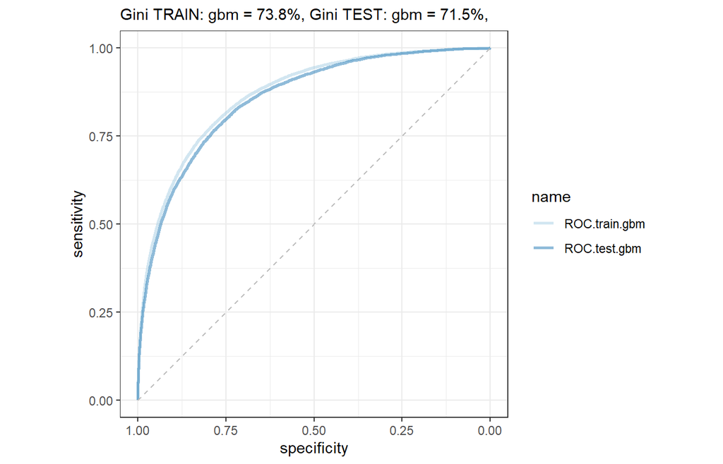

Because of unbalanced data we decided to take the geometric mean of sensitivity and specificity in order to find the balance between them, so we could have the most desirable threshold.

```
## [1] 0.223338
```

After finding the optimal threshold we decided to classify predictions 1 and 0 with that threshold in order to calculate the confusion matrix and evaluate our model.

#### 8.2.1.2 Confusion Matrix

```
## Confusion Matrix and Statistics
##
##           Reference
## Prediction     0     1
##          0 25961  2231
##          1  7133  7332
##
##                Accuracy : 0.7805
##                  95% CI : (0.7765, 0.7844)
##     No Information Rate : 0.7758
##     P-Value [Acc > NIR] : 0.01047
##
##                   Kappa : 0.4662
##
##  Mcnemar's Test P-Value : < 2e-16
##
##             Sensitivity : 0.7845
##             Specificity : 0.7667
##          Pos Pred Value : 0.9209
##          Neg Pred Value : 0.5069
##              Prevalence : 0.7758
##          Detection Rate : 0.6086
##    Detection Prevalence : 0.6609
##       Balanced Accuracy : 0.7756
##
##        'Positive' Class : 0
##
```

We can see from our confusion matrix that the accuracy of the model is 78%, Sensitivity 0.7845 and Specificity : 0.7667. Kappa coefficient is 0.4662 which indicates there is moderate agreement between frequencies of two sets of data.

Precision: 0.9208641  
Recall: 0.7844624  
F-1 Score: 0.8472082

## 8.3 XGBoost

Due to the unsatisfactory effects on the default parameters, it was decided to tune the XGBoost model. The process began with finding the optimal minimal child weight and then jumped to other ones.

In the next steps, a wide variety of parameters were used for validation and proceeded with the most efficient one while changing the validated parameter for the very next one.

The final version of the model is presented in the code below.

```r
parameters_xgb <- expand.grid(nrounds = 100,
                             max_depth = 6,
                             eta = 0.3,
                             gamma = 0,
                             colsample_bytree = 1,
                             min_child_weight = 1,
                             subsample = 0.9)
ctrl_cv3 <- trainControl(method = "cv",
                         number = 3,
                         classProbs = TRUE,
                         summaryFunction = twoClassSummary)
```

```r
if (0) {
  Rain.xgb <- train(model.formula,
                     data = rain_train,
                     method = "xgbTree",
                     trControl = ctrl_cv3,
                     tuneGrid  = parameters_xgb)
  Rain.xgb
  Rain.xgb %>% saveRDS(here("Rain.xgb.rds"))
}
Rain.xgb <- readRDS(here("Rain.xgb.rds"))
Rain.xgb
```

[output not shown]

```r
rain.pred.train.xgb <- predict(Rain.xgb,
                                  rain_train,
                                  type = "prob",
                                  n.trees = 500)

rain.pred.test.xgb <- predict(Rain.xgb,
                                 rain_test,
                                 type = "prob",
                                 n.trees = 500)
```

### 8.3.1 Results

#### 8.3.1.1 Gini

After several attempts, it was possible to obtain the most optimal model.

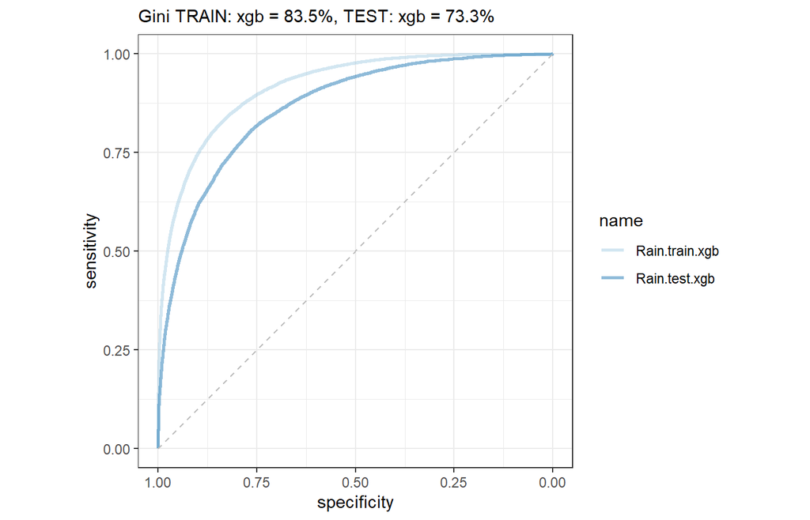

We will take the geometric mean in order to find the balance between the sensitivity and the specificity, so we could have the most desirable threshold.

```
## [1] 0.198438
```

After finding the optimal threshold we decided to classify predictions 1 and 0 with that threshold in order to calculate the confusion matrix and evaluate our model.

#### 8.3.1.2 Confusion Matrix

```
## Confusion Matrix and Statistics
##
##           Reference
## Prediction     0     1
##          0 25268  1841
##          1  7826  7722
##
##                Accuracy : 0.7734
##                  95% CI : (0.7694, 0.7773)
##     No Information Rate : 0.7758
##     P-Value [Acc > NIR] : 0.8874
##
##                   Kappa : 0.4671
##
##  Mcnemar's Test P-Value : <2e-16
##
##             Sensitivity : 0.7635
##             Specificity : 0.8075
##          Pos Pred Value : 0.9321
##          Neg Pred Value : 0.4967
##              Prevalence : 0.7758
##          Detection Rate : 0.5924
##    Detection Prevalence : 0.6355
##       Balanced Accuracy : 0.7855
##
##        'Positive' Class : 0
##
```

Precision: 0.932089  
Recall: 0.7635221  
F-1 Score: 0.8394266

# 9 Models comparison

Both GBM and XGBoost follows the principle of gradient boosting. There are some difference in modeling details. XGBoost uses a more regularized model formalization to control over-fitting, which gives it better performance than GBM.

Another difference is that XGBoost using less computations resources for boosted tree algorithms. And that is also one of the main reason why it is so popular.

In the following table we can see how 2 model performed in our dataset with the following scores.

```
##                                  GBM   XGBoost
## Threshold                  0.2233380 0.1984380
## Area Under the Curve (AUC) 0.8572642 0.8667172
## Accuracy                   0.7804815 0.7733783
## F1                         0.8472082 0.8394266
## Sensitivity                0.7844624 0.7635221
## Specificity                0.7667050 0.8074872
## Kappa                      0.4662066 0.4670830
## Precision                  0.9208641 0.9320890
## Recall                     0.7844624 0.7635221
```

# 10 Summary

To sum up, in this project we tried to find out which model would perform better on predicting if it is going to rain next day or not based on the dataset from many locations across Australia 10 years of daily weather observations. We used GBM and XGBoost models to do the predictions, ROC curve to find the best threshold and Area Under Curve (AUC), Accuracy, F1 Score, Sensitivity, Specificity, Precision and Recall to evaluate the models.

According to the results we found out that based in AUC, XGBoost performs better than GBM. If it comes to performance with the optimum thresholds GBM get better scores in Accuracy, F1, Sensitivity and Recall while XGBoost got better scores on Specificity and Precision. In our case we decided to have more balanced and that’s why we used geometric mean but threshold can be changed and set up in order to get more true positives or true negatives but every cases would have some penalty which would en up with having either more False negatives or more false positives.